# Car Manufacturer Dataset Analysis

Aisling Towey

22 March 2019

## Project Summary

The objective of this project is to carry out analysis on a car manufacturer’s data to predict the time it takes to complete a check on each car before it is released from the manufacturer. The purpose of this prediction is to provide recommendations on how the time for each check can be reduced.

## Background

The data provided consists of 4209 observations and 378 variables. The outcome variable labelled ‘y’ contains the time it takes to complete a check of each car and the data also contains and ID variable for each check. The remaining variables are all binary variables excluding 8 rows containing factor variables. The names of these remaining variables are labeled from X0 to X385 giving no indication of the meaning of the variables.

## Process of Analysis

The initial step taken in the analysis was to identify the type of analysis that was required. As the outcome variable is continuous and the aim is to predict the variable, it is evident that this is a regression prediction problem.

The next step was to carry out exploratory data analysis which involved checking for missing values, checking for multicollinearity, identifying outliers, removing zero variance columns, creating plots of variables, encoding factor variables and exploring the response variable.

Following the exploratory data analysis phase, different models were evaluated to identify the most appropriate for this scenario. The models selected were:

- Linear Regression
- XGBoost
- Random Forest

Different variations of the selected models were trialied by including principal component analysis and altering the tuning and parameters of the models. As dimensionality is a key feature of this dataset with many variables, principal component analysis was also identified as a useful technique to reduce dimensionality. Before running the models the data was split into a training and test set. 80% of the data was put into the training set and 20% into the test set. The training set was used to train the model and the test set was used to ensure the model generalized well on unseen data. R-squared is the metric used in this analysis to select the best model. Higher r-squared values signify better models. R-squared is deemed more appropriate in this scenario than root mean squared error (RMSE) as it is a relative metric with values ranging from 0 to 1 which makes it easier to interpret. RMSE is used to support the r-squared findings. Lower RMSE values signify better models.

## Results

The results of the models as illustrated in figure 1 show the random forest model achieves the highest r-squared value of 0.56 and the lowest RMSE value of 8.28. When the model is used to predict the outcome of the test set, the random forest model achieves an r-squared value of 0.57 and an RMSE value of 8.28 meaning the model generalized well on new data.

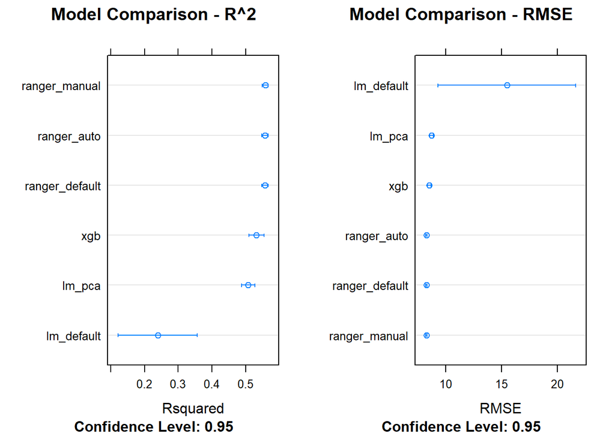

Comparison of models showing random forest as the best model

The variables in the dataset found to be most important to the random forest model are X127, X261 and X314 as in figure 2. The model relies significantly more on these variables than any other variables in the dataset. These variables all occur more than 1700 times in the dataset meaning they appear in at least 40% of checks.

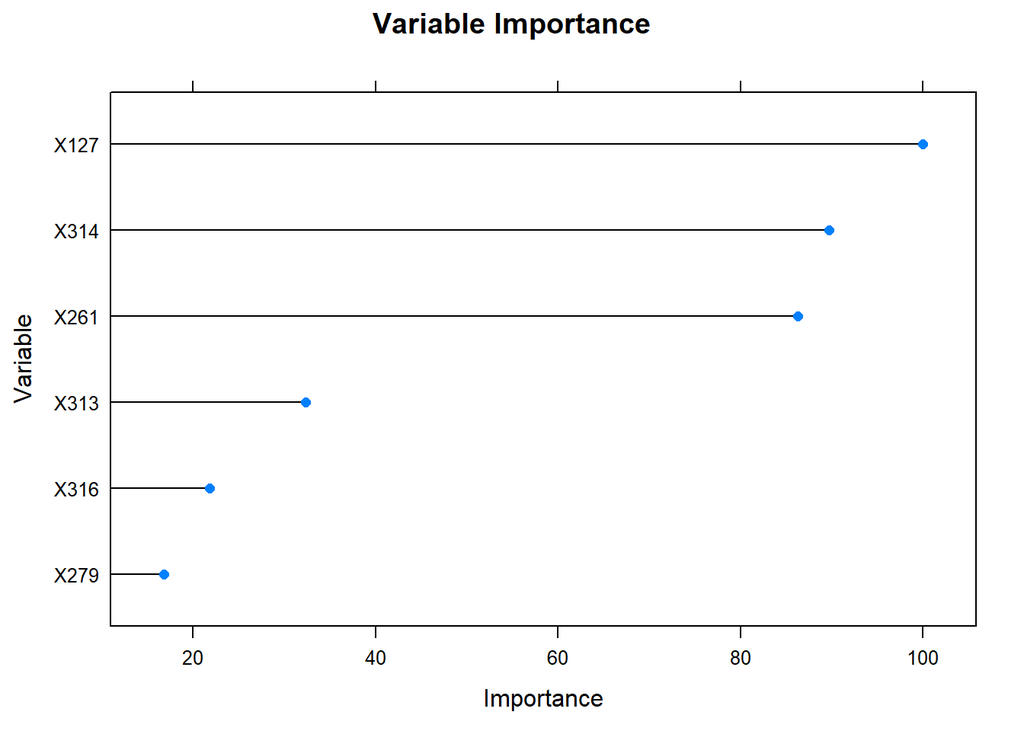

Relative importance of top 6 variables the random forest model relies on

## Recommendations

The results of this analysis suggest that focusing of the variables X127, X261 and X314 when conducting checks may be beneficial in reducing the time taken to complete each check. An understanding of the meaning of these variables would be required to make more specific recommendations of what this may involve.

## Limitations

The main limitation of this analysis is that there is no codebook or data dictionary available explaining the meaning of each variable. An understanding of the variables would allow for more specific models, increased understanding of the results and improved recommendations.